# Assignment-1

```r
library(sf)
library(tidyverse)
library(ggspatial)
library(ggthemes)

public <- st_read("https://services5.arcgis.com/GfwWNkhOj9bNBqoJ/arcgis/rest/services/Privately_Owned_Public_Spaces/FeatureServer/0/query?where=1=1&outFields=*&outSR=4326&f=pgeojson")
nhoods <- st_read("https://services5.arcgis.com/GfwWNkhOj9bNBqoJ/arcgis/rest/services/NYC_Neighborhood_Tabulation_Areas_2020/FeatureServer/0/query?where=1=1&outFields=*&outSR=4326&f=pgeojson")
health <- st_read("https://services5.arcgis.com/GfwWNkhOj9bNBqoJ/arcgis/rest/services/NYC_Health_Centers/FeatureServer/0/query?where=1=1&outFields=*&outSR=4326&f=pgeojson")
```

public_plot <- ggplot(nhoods) + geom_sf() + geom_sf(alpha = 0.5)

public_plot

nhoods_plot <- ggplot(nhoods) + geom_sf() + geom_sf(alpha = 0.3)

public_plot <- ggplot(public) + geom_sf() + geom_sf(color = “blue”)

public_plot

public2_plot <-ggplot(public) + geom_sf() + geom_sf(color = “blue”)

public2_plot

nhoods_plot + geom_sf() + geom_sf(data = public, color = “blue”, alpha = 0.5, shape = 1)

ggplot() + geom_sf(data = nhoods, color = “gray”, size = 1, fill = “black”, alpha = 0.5) + geom_sf(data = public, color = “blue”)

layer1_map <-ggplot() + geom_sf(data = nhoods, color = “gray”, size = 1, fill = “black”, alpha = 0.5) + geom_sf(data = public, shape = 15, color = “blue”, alpha = 0.6)

layer1_map

nhoods2_plot <-ggplot() + geom_sf(data = nhoods, color = “gray”, size = 0.5, fill = “black”, alpha = 0.5)

nhoods2_plot

nhoods2_plot + geom_sf(data = public, color = “blue”, shape = 15, alpha = 0.7)

ggplot() + geom_sf(data = nhoods, color = “gray”, size = 0.3, fill = “black”, alpha = 0.5, aes(fill = “NYC Neighborhoods”)) + geom_sf(data = public, color = “blue”, shape = 15, alpha = 0.9) + scale_fill_manual(values = “gray”, name = "")

ggplot() + geom_sf(data = nhoods, color = “gray”, alpha = 0.5, size = 0.3 aes(fill = “NYC Neighborhoods”)) + geom_sf(data = public, color = “blue”) + scale_fill_manual(values = “gray”, name = "")

ggplot() + geom_sf(data = nhoods, color = “NA”, alpha = 0.5 aes(fill = “NYC Neighborhoods”)) + geom_sf(data = public, color = “blue”) + scale_fill_manual(values = “black”, name = "")

ggplot(health) + annotation_map_tile(zoomin = 0, progress = “none”) + geom_sf() + labs(caption = “Map tiles and data by OpenStreetMap”)

ggplot(public) + annotation_map_tile(zoomin = 0, progress = “none”, type = “hotstyle”) + geom_sf() + labs(caption = “Map tiles and data by OpenStreetMap”)

ggplot() + geom_sf(data = nhoods, color = “NA”, alpha = 0.5, aes(fill = “NYC Neighborhoods”)) + geom_sf(data = public, color = “blue”) + scale_fill_manual(values = “black”, name = "")

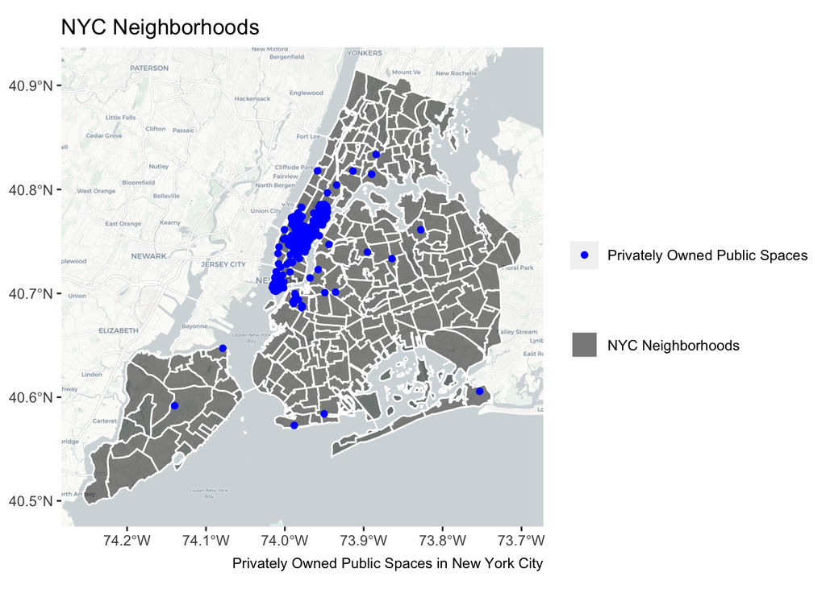

```r
ggplot() +
  ggtitle("NYC Neighborhoods") +
  annotation_map_tile(zoomin = 0, progress = "none", type = "cartolight") +
  geom_sf(data = nhoods, color = "white", alpha = 0.5,
          aes(fill = "NYC Neighborhoods")) +
  geom_sf(data = public,
         aes(color = "Privately Owned Public Spaces")) +
  scale_fill_manual(values = "black", name = "") +
  scale_color_manual(values = c("blue"), name = "") +
  labs(caption = "Privately Owned Public Spaces in New York City")
```

[figure not shown]

```r
ggplot() +
  annotation_map_tile(zoomin = 0, progress = "none", type = "cartolight") +
  geom_sf(data = health, color = "NA", alpha = 0.5,
          aes(fill = "NYC Neighborhoods")) +
  geom_sf(data = public,
         aes(color = "Privately Owned Public Spaces")) +
  scale_fill_manual(values = "black", name = "") +
  scale_color_manual(values = c("blue"), name = "") +
  labs(caption = "Privately Owned Public Spaces in New York City")
```

pdf(“A1_draft.pdf”, width = 5, height = 3) draftmap_plot dev.off()

pdf(“A1big_draft.pdf”, width = 10, height = 6) draftmap_plot dev.off()